# Meta®egr

Mateusz Bąkała & Dominik ®afacz

26 marca 2019

[figure not shown]

Celem tego dokumentu jest zilustrowanie procesu tworzenia oraz zasady działania pakietu Meta®egr: almost part of Tidyverse.

# Zebrane dane

Zmiennymi w zbiorze modeli są:

- **columns** – liczba kolumn datasetu
- **insts** – liczba wierszy datasetu
- **model_param** – nazwa modelu oraz wybrana opcja jednego różnicującego parametru; rozpatrywane modele to:
  - regr.svm
  - regr.plsr
  - regr.gausspr
- **target_iqr** – rozstęp międzykwartylny zmiennej target
- **target_diff** – różnica między minimum i maksimum zmiennej target
- **target_skewness** – skośność zmiennej target (z przedziału [-1, 1])
- **binary_factors** – liczba zmiennych predykcyjnych będących faktorami o dwóch (lub mniej) klasach
- **factors3to5** – liczba zmiennych predykcyjnych będących faktorami o trzech do pięciu klasach
- **big_factors** – liczba zmiennych predykcyjnych będących faktorami o więcej niż pięciu klasach
- **nonskew_numerics** – liczba zmiennych predykcyjnych ciągłych o bezwzględnej skośności nie większej niż 0.2
- **small_skew_numerics** – liczba zmiennych predykcyjnych ciągłych o bezwzględnej skośności z przedziału (0.2, 0.5]
- **big_skew_numerics** – liczba zmiennych predykcyjnych ciągłych o bezwzględnej skośności większej niż 0.5
- **r2** – kolumna docelowa predykcji wskazująca, czy parametr r2 danego modelu jest większy, czy mniejszy od zadanego progu

|  | target_iqr | binary_factors | nonskew_numerics | insts | r2 |
| --- | --- | --- | --- | --- | --- |
| 1 | 1.0000 | 0 | 1 | 10339 | TRUE |
| 84 | 0.3778 | 0 | 8 | 8192 | FALSE |
| 56 | 9.3000 | 1 | 3 | 768 | FALSE |
| 57 | 35414.9640 | 0 | 3 | 662 | FALSE |
| 123 | 0.3810 | 1 | 1 | 61 | FALSE |

# Trening

Do uczenia użyliśmy po długich perypetiach lasu losowego. Poniżej wyniki treningu z progiem **r2** ustawionym na 0.5:

```
##         predicted
## true     FALSE TRUE -err.-
##   FALSE     30    9      9
##   TRUE       4   17      4
##   -err.-     4    9     13
```

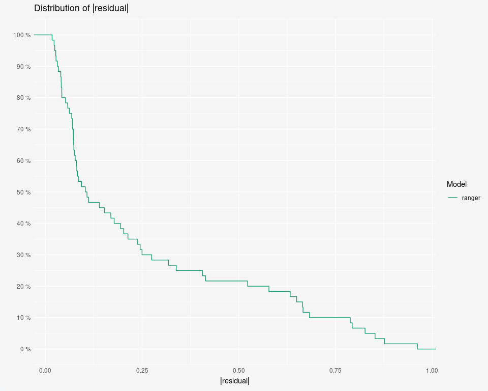

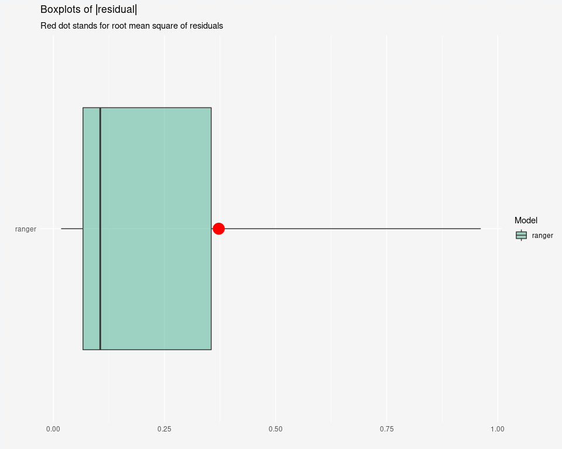

```
##        predicted
## true    FALSE     TRUE
##   FALSE 30        9         tpr: 0.77 fnr: 0.23
##   TRUE  4         17        fpr: 0.19 tnr: 0.81
##         ppv: 0.88 for: 0.35 lrp: 4.04 acc: 0.78
##         fdr: 0.12 npv: 0.65 lrm: 0.29 dor: 14.17
##
##
## Abbreviations:
## tpr - True positive rate (Sensitivity, Recall)
## fpr - False positive rate (Fall-out)
## fnr - False negative rate (Miss rate)
## tnr - True negative rate (Specificity)
## ppv - Positive predictive value (Precision)
## for - False omission rate
## lrp - Positive likelihood ratio (LR+)
## fdr - False discovery rate
## npv - Negative predictive value
## acc - Accuracy
## lrm - Negative likelihood ratio (LR-)
## dor - Diagnostic odds ratio
```

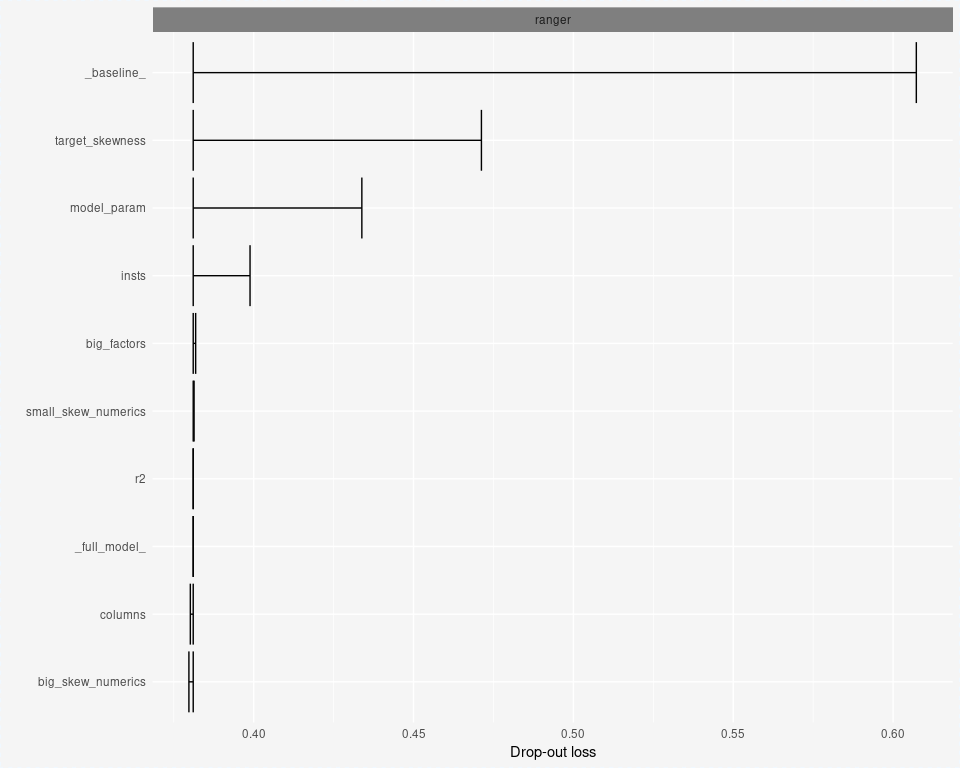

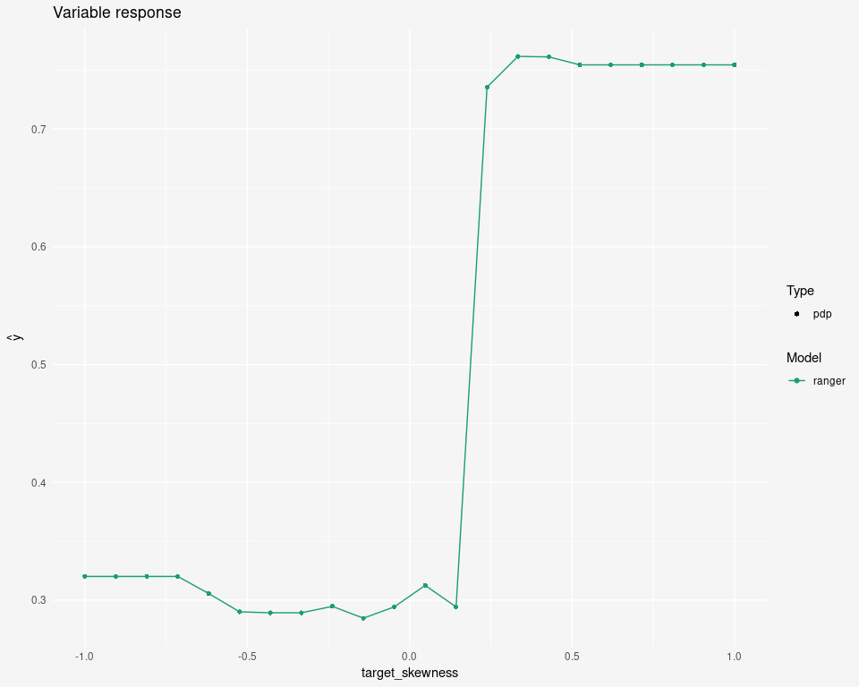

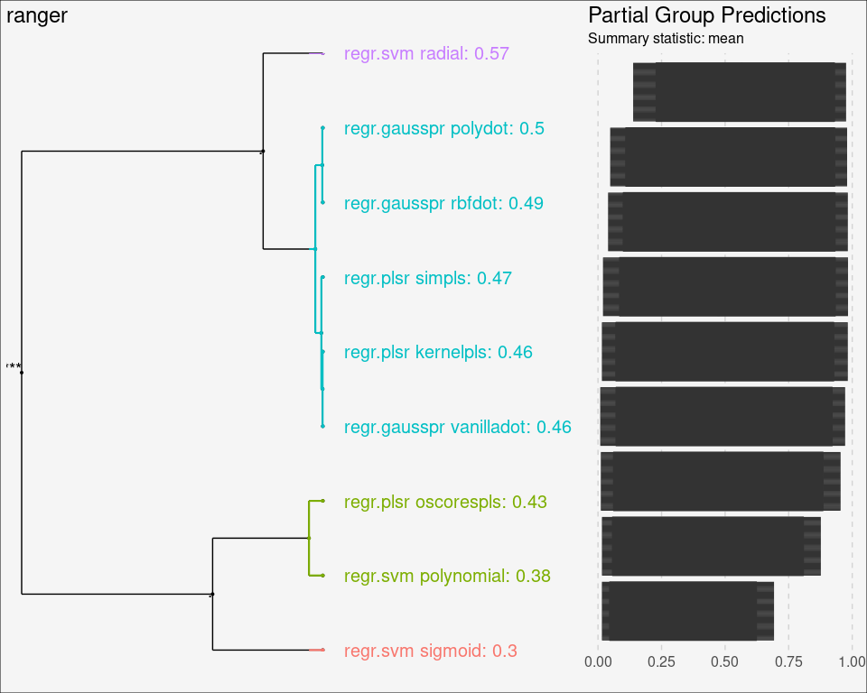

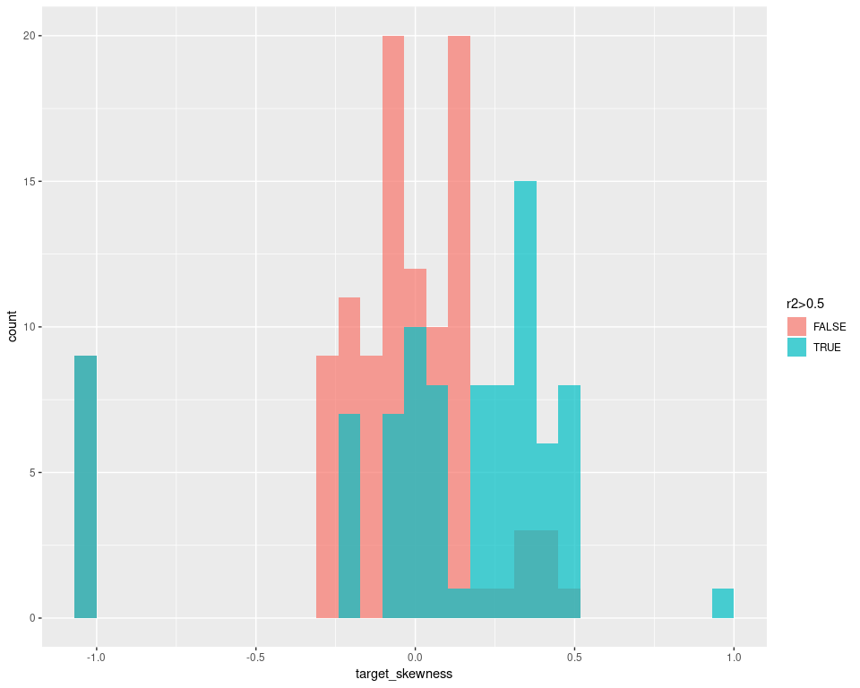

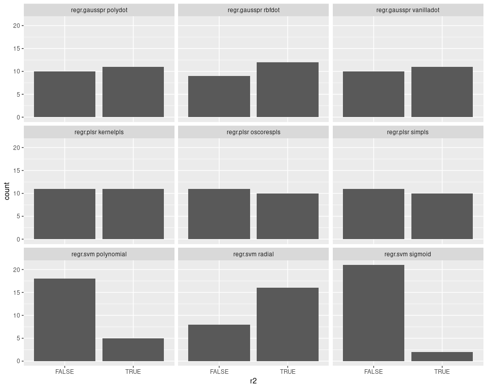

# Wnioski i obserwacje

- trudno jest przewidywać regresję
- przydałoby się więcej danych
- warto by przechowywać więcej informacji o zmiennych (np. odchylenie standardowe)
- DALEX nie pozwala porównywać takich samych modeli mlr, ale o np. różnych parametrach